# Análise de Dados em R

Cláudio A. Monteiro

23 de Janeiro, 2018

## **PRÁTICA EM R**

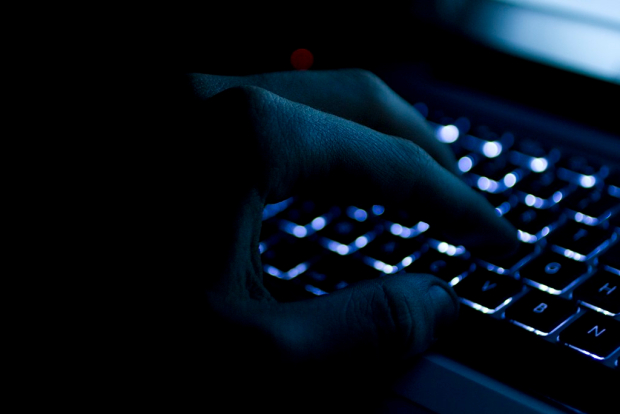

### Agora vamos por a mão na massa!

A partir de agora iremos começar a trabalhar diretamente com a linguagem R, compreendendo seus conceitos e operaões mais básicas.

**Atenço!** Abra um *Script* e salve-o com o nome que desejar, numa pasta especifica para seus estudos em R. é muito importante que você acompanhe o texto com o RStudio aberto, inserindo e executando os códigos no Script. Para tal você deve estar com a barra “|” piscando na mesma linha do código que quer executar, entÃ£o aperte *Ctrl + Enter (Windows/Linux)* ou *Command + Enter (MAC)*.

A funcionalidade mais básica do R Ã© atuar como uma calculadora. Podemos fazer alguns cálculos básicos como:

```r
3 + 5               # soma
183082 - 21982      # subtraço
92 * 1.6            # multiplicaço
900 / 30            # divisÃ£o
40**2               # exponencial
```

### **Funço**

Uma *funço* é um *comando* que irá executar uma série de tarefas que lhe foi designada. Tudo o que *acontece* no R é uma funço. A funço sqrt() , por exemplo, nos retorna a raiz quadrada do que estiver entre parênteses:

```r
sqrt(9)
```

```
[1] 3
```

O R tambÃ©m trabalha com operaões lógicas, retornando TRUE ou FALSE a partir da lógica que testamos.

```r
2 == 3       # 2 igual a 3
2 != 3       # 2 diferente de 3
2 < 3        # 2 menor do que 3
2 <= 3       # 2 menor ou igual a 3
2 > 3        # 2 maior do que 3
2 >= 3       # 2 maior ou igual a 3
```

### **Objeto**

Um conceito fundamental para entendermos o funcionamento da linguagem R Ã© o de programaço orientada a objetos.

Objetos do mundo real têm duas caracteristicas: todos tem *estado* e *comportamento*. Gatos possuem estado (nome, cor, cheiro, fome) e comportamento (miar, pular, ronronar). Identificar o estado e comportamento de objetos do mundo real Ã© uma ótima maneira de começar a pensar em termos de programaço orientada a objetos.

Pare um pouco agora e olhe ao seu redor, observa os objetos que estÃ£o ao seu redor. Para cada objeto que você vê, pergunte a si mesmo: âEm quais possiveis estados que este objeto pode estar?â e âquais possiveis comportamentos este objeto pode ter?â. Anote suas observaões em um papel.

Você deve notar que objetos do mundo real variam em complexidade, a lâmpada do seu quarto tem dois possiveis estados (ligada e desligada) e dois possiveis comportamentos (ligar, desligar), mas seu ventilador, por exemplo, pode ter uma maior variabilidade de estados (ligado, velocidade atual, desligado, posicionado para cima, posicionado para baixo) e comportamentos (aumentar velocidade, diminuir velocidade, desligar , girar, parar). Você também pode notar que alguns objetos estão dentro de outros objetos (uma caneta dentro de um estojo, um café dentro de um copo). Todas essas observaões do mundo real são traduzidas para o mundo da programaço orientada a objetos.

Objetos computacionais são conceitualmente similares a objetos do mundo real: eles também possuem estado e comportamento. Um objeto armazena seu estado em **classes** (varia de acordo com a linguagem de programaço) e expõe seu comportamento por meio de **funões**.

No R, tudo aquilo que **existe** Ã© um objeto. Os objetos salvos aparecem no Environment, localizado no canto direito superior da tela do *RStudio*.